# Toronto Bike Rack Map (February 2021)

Laura Cline

23/02/2021

The `leaflet` package is originally a JavaScript library of the same name that has been brought over to R. It makes it easy to make interactive maps. The basics are fairly similiar to the `ggmap` set-up, but there are many other new options.

In the same way as a graph in `ggplot` function, a map in the leaflet package begins with a call to the `leaflet()` function. This allows you to specify data, and a bunch of other options such as width and height. After this, we add ‘layers’ in the same way that we added them in `ggplot`. The first layer that we will add is a tile with the function `addTiles()`. In this case, the default is from OpenStreetMap. After that, we will add markets that show the location of each bike parking spot with `addMarkers()`.

## Load and Clean Data

```r
# This code is based on code from: https://open.toronto.ca/dataset/street-furniture-bicycle-parking/.
# install.packages("opendatatoronto")

library(opendatatoronto)
library(tidyverse)
raw_data <- read_csv("bike_parking.csv")
raw_data
```

```
## # A tibble: 16,998 x 20
##     `_id` OBJECTID ID    ADDRESSNUMBERTE… ADDRESSSTREET FRONTINGSTREET SIDE
##     <dbl>    <dbl> <chr> <chr>            <chr>         <chr>          <chr>
##  1 7.63e6        2 BP-1… 70               The Pond Rd   <NA>           <NA>
##  2 7.63e6        7 BP-1… 8                Assiniboine … <NA>           <NA>
##  3 7.63e6       66 BP-0… 8                Kensington A… <NA>           <NA>
##  4 7.63e6      108 BP-1… 21               Canniff St    <NA>           <NA>
##  5 7.63e6      171 BP-1… 359              King St E     <NA>           <NA>
##  6 7.63e6      219 BP-1… 1960             Queen St E    <NA>           <NA>
##  7 7.63e6      244 BP-1… 87               Avenue Rd     Avenue Rd      East
##  8 7.63e6      275 BP-0… 50               Blue Jays Way <NA>           <NA>
##  9 7.63e6      289 BP-0… 1313             Bloor St W    <NA>           <NA>
## 10 7.63e6      323 BP-0… 189              Dundas St E   <NA>           <NA>
## # … with 16,988 more rows, and 13 more variables: FROMSTREET <chr>,
## #   DIRECTION <chr>, SITEID <dbl>, WARD <dbl>, BIA <chr>, ASSETTYPE <chr>,
## #   STATUS <chr>, SDE_STATE_ID <dbl>, X <dbl>, Y <dbl>, LONGITUDE <dbl>,
## #   LATITUDE <dbl>, geometry <chr>
```

```r
# Remove irrelevant dimensions

bike_data <- tibble(ward = raw_data$WARD,
                    id = raw_data$ID,
                    status = raw_data$STATUS,
                    street_address = paste(raw_data$ADDRESSNUMBERTEXT, raw_data$ADDRESSSTREET),
                    latitude = raw_data$LATITUDE,
                    longitude = raw_data$LONGITUDE)
```

```r
# Remove the temporary bike racks

bike_data <-
  bike_data %>%
  filter(status == "Existing") %>%
  select(-status)

bike_data <-
  bike_data %>%
  filter(ward == 11) %>%
  select(-ward)
```

```r
#Write dimension reduced data to a csv

write_csv(bike_data, "bike_data.csv")
```

# Static Map of Bike Rack Locations in Toronto (February 2021)

```r
# install.packages("ggmap")
library(ggmap)
```

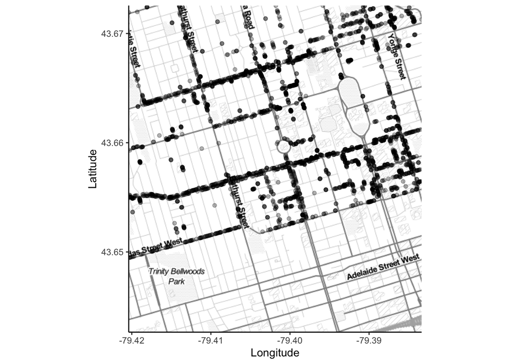

```r
# Grab our tile and add our bike rack data

bbox <- c(left = -79.420390, bottom = 43.642658, right = -79.383354, top = 43.672557)

toronto_stamen_map <- get_stamenmap(bbox, zoom = 14, maptype = "toner-lite")
ggmap(toronto_stamen_map, maprange = FALSE) +
  geom_point(data = bike_data,
             aes(x = longitude,
                 y = latitude),
             alpha = 0.3) +
  labs(x = "Longitude",
       y = "Latitude") +
  theme_classic()
```

# Interactive Map of Bike Rack Locations in Toronto (February 2021)

```r
# install.packages("leaflet")
library(leaflet)

leaflet(data = bike_data) %>%
  addTiles() %>%
  addMarkers(lng = bike_data$longitude,
             lat = bike_data$latitude,
             popup = bike_data$street_address,
             label = ~as.character(bike_data$street_address))
```

[interactive chart not shown]

`popup` is what happens when you clock on the marker. In this example, it gives the address. The second is `label` which is what happens when you hover over the market. In this example, it also gives the street address.